# **The Impact of Structure on Software Merging: Semistructured versus Structured Merge**

## Abstract

Merge conflicts often occur when developers concurrently change the same code artifacts. While state-of-practice unstructured merge tools (e.g git merge) try to automatically resolve merge conflicts via textual similarity, semistructured and structured merge tools try to go further by exploiting the syntactic structure and semantics of the involved artifacts. Although there is evidence that semistructured merge has significant advantages over unstructured merge, and that structured merge reports significantly less conflicts than unstructured merge, it is unknown how semistructured merge compares with structured merge. In an empirical study, we compare semistructured and structured merge by reproducing more than 40,000 merge scenarios from more than 500 projects. We assess how often the tools report different results. We also identify conflicts incorrectly reported by one tool but not by the other (false positives), and conflicts correctly reported by one tool but missed by the other (false negatives). Our results show that the tools differ on 24% of the scenarios with conflicts. Semistructured merge reports more false positives, whereas structured merge has more false negatives. Finally, we observe that adapting a semistructured merge tool to resolve a particular kind of conflict makes semistructured and structured merge even closer.

- [Preprint](https://github.com/spgroup/s3m/tree/master/svj/preprint.pdf)
- [Replication Package](https://github.com/spgroup/s3m/tree/master/svj/replication/)

## How many conflicts arise from the use of semistructured and structured merge?

There is a difference of **1.29%** in the number of reported conflicts.

|  | Semistructured Merge | Structured Merge |
| --- | --- | --- |
| 1 | 4732 | 4793 |

Merge scenarios had at least one conflict with *semistructured* merge on average **2.25%** of the considered merge scenarios, with a standard deviation of **4.58%** . Considering aggregated numbers of all projects of our sample, this corresponds to **2.31%** of the considered merge scenarios. Besides that, merge scenarios had at least one conflict with *structured* merge on average **1.8%** of the considered merge scenarios, with a standard deviation of **3.92%** . Considering aggregated numbers of all projects of our sample, this corresponds to **1.87%** of the considered merge scenarios.

|  | Project | Merge Scenarios | Conflicting Semistructured Merge Scenarios | Conflicting Structured Merge Scenarios |
| --- | --- | --- | --- | --- |
| 1 | webcam-capture | 27 | - | - |
| 2 | brickhouse | 9 | - | - |
| 3 | kryo-serializers | 22 | - | - |
| 4 | optiq | 7 | - | - |
| 5 | QRGen | 45 | - | - |
| 6 | fenixedu-academic | 897 | - | - |
| 7 | webapp-runner | 11 | 3 | - |
| 8 | Xebium | 30 | 2 | 2 |
| 9 | Metamorphosis | 5 | - | - |
| 10 | zxing | 74 | - | - |

[output cut: 453 more lines]

Statistical significance, consider a confidence level of 0.95 (p-value = 0.05):

```
##
##  Wilcoxon signed rank test with continuity correction
##
## data:  cf_SS$Semistructured and cf_ST$Structured
## V = 4013.5, p-value = 2.938e-13
## alternative hypothesis: true location shift is not equal to 0
```

Strength/magnitude of the statistical claim (*effect size*):

```
##
## Cliff's Delta
##
## delta estimate: 0.03353025 (negligible)
## 95 percent confidence interval:
##       lower       upper
## -0.03204124  0.09881434
```

## How often do semistructured and structured merge differ with respect to conflict occurrence?

### By All Scenarios

The tools differ on average **0.52%** of the considered merge scenarios, with a standard deviation of **2.06%** . Considering aggregated numbers of all projects of our sample, this corresponds to **0.58%** of the considered merge scenarios.

|  | Project | Merge Scenarios | Conflicting Merge Scenarios Only With Semistructured Merge | Conflicting Merge Scenarios Only With Structured Merge | % |
| --- | --- | --- | --- | --- | --- |
| 1 | webcam-capture | 27 | - | - | 0 |
| 2 | brickhouse | 9 | - | - | 0 |
| 3 | kryo-serializers | 22 | - | - | 0 |
| 4 | optiq | 7 | - | - | 0 |
| 5 | QRGen | 45 | - | - | 0 |
| 6 | fenixedu-academic | 897 | - | - | 0 |
| 7 | webapp-runner | 11 | 3 | - | 27.27 |
| 8 | Xebium | 30 | - | - | 0 |
| 9 | Metamorphosis | 5 | - | - | 0 |
| 10 | zxing | 74 | - | - | 0 |

[output cut: 453 more lines]

### By Conflicting Scenarios

The tools differ on average **23.22%** of the considered merge scenarios, with a standard deviation of **44.45%** . Considering aggregated numbers of all projects of our sample, this corresponds to **23.67%** of the considered merge scenarios.

[output not shown]

[output cut: 453 more lines]

### When there is chance of conflicts in Files

The tools differ on average **4.09%** of the considered merge scenarios, with a standard deviation of **13.26%** . Considering aggregated numbers of all projects of our sample, this corresponds to **5.16%** of the considered merge scenarios.

|  | Project | Merge Scenarios With Common Changed Files | Conflicting Merge Scenarios Only With Semistructured Merge | Conflicting Merge Scenarios Only With Structured Merge | % |
| --- | --- | --- | --- | --- | --- |
| 1 | webcam-capture | - | - | - | 0 |
| 2 | brickhouse | - | - | - | 0 |
| 3 | kryo-serializers | 1 | - | - | 0 |
| 4 | optiq | 1 | - | - | 0 |
| 5 | QRGen | 3 | - | - | 0 |
| 6 | fenixedu-academic | 44 | - | - | 0 |
| 7 | webapp-runner | 4 | 3 | - | 75 |
| 8 | Xebium | 8 | - | - | 0 |
| 9 | Metamorphosis | - | - | - | 0 |
| 10 | zxing | - | - | - | 0 |

[output cut: 453 more lines]

### Boxplot

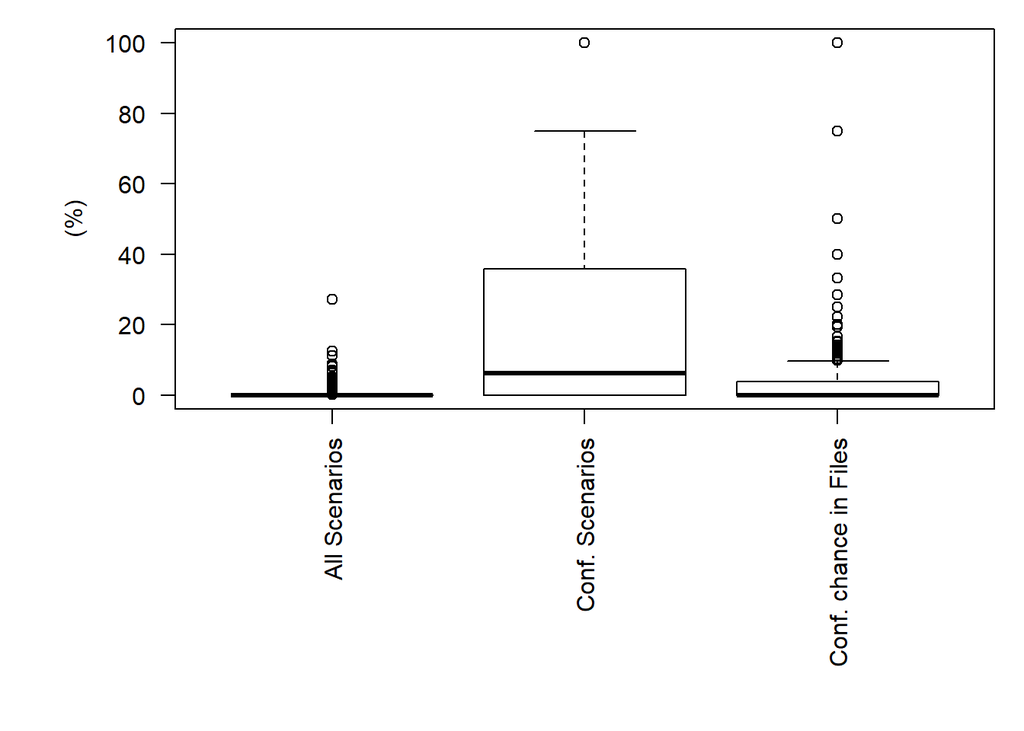

## Which strategy reports fewer false positives?

### Semistructured Merge Additional False Positives

#### By All Scenarios

On average **0.1%** of the considered merge scenarios, had semistructured merge additional falses positives, with a standard deviation of **0.73%** . Considering aggregated numbers of all projects of our sample, this corresponds to **0.09%** of the considered merge scenarios.

|  | Project | Merge Scenarios | Merge Scenarios with Semistructured Merge Additional False Positives * | % |
| --- | --- | --- | --- | --- |
| 1 | webcam-capture | 27 | - | 0 |
| 2 | brickhouse | 9 | - | 0 |
| 3 | kryo-serializers | 22 | - | 0 |
| 4 | optiq | 7 | - | 0 |
| 5 | QRGen | 45 | - | 0 |
| 6 | fenixedu-academic | 897 | - | 0 |
| 7 | webapp-runner | 11 | - | 0 |
| 8 | Xebium | 30 | - | 0 |
| 9 | Metamorphosis | 5 | - | 0 |
| 10 | zxing | 74 | - | 0 |

[output cut: 453 more lines]

### Structured Merge Additional False Positives

#### By All Scenarios

On average **0.01%** of the considered merge scenarios, had structured merge additional falses positives, with a standard deviation of **0.17%** . Considering aggregated numbers of all projects of our sample, this corresponds to **0.01%** of the considered merge scenarios.

|  | Project | Merge Scenarios | Merge Scenarios with Structured Merge Additional False Positives * | % |
| --- | --- | --- | --- | --- |
| 1 | webcam-capture | 27 | - | 0 |
| 2 | brickhouse | 9 | - | 0 |
| 3 | kryo-serializers | 22 | - | 0 |
| 4 | optiq | 7 | - | 0 |
| 5 | QRGen | 45 | - | 0 |
| 6 | fenixedu-academic | 897 | - | 0 |
| 7 | webapp-runner | 11 | - | 0 |
| 8 | Xebium | 30 | - | 0 |
| 9 | Metamorphosis | 5 | - | 0 |
| 10 | zxing | 74 | - | 0 |

[output cut: 453 more lines]

Statistical significance, consider a confidence level of 0.95 (p-value = 0.05):

```
##
##  Wilcoxon signed rank test with continuity correction
##
## data:  aFP_ST$Structured and aFP_SS$Semistructured
## V = 70.5, p-value = 0.0003034
## alternative hypothesis: true location shift is not equal to 0
```

Strength/magnitude of the statistical claim (*effect size*):

```
##
## Cliff's Delta
##
## delta estimate: -0.09988568 (negligible)
## 95 percent confidence interval:
##       lower       upper
## -0.12304102 -0.07662165
```

## Which strategy has fewer false negatives?

### Semistructured Merge Additional False Negatives

#### By All Scenarios

On average **0%** of the considered merge scenarios, had semistructured merge additional falses negatives, with a standard deviation of **0.06%** . Considering aggregated numbers of all projects of our sample, this corresponds to **0.01%** of the considered merge scenarios.

|  | Project | Merge Scenarios | Semistructured Merge Scenarios with Compilation Issues * | Semistructured Merge Scenarios with Failed Tests * | % |
| --- | --- | --- | --- | --- | --- |
| 1 | webcam-capture | 27 | - | - | 0 |
| 2 | brickhouse | 9 | - | - | 0 |
| 3 | kryo-serializers | 22 | - | - | 0 |
| 4 | optiq | 7 | - | - | 0 |
| 5 | QRGen | 45 | - | - | 0 |
| 6 | fenixedu-academic | 897 | - | - | 0 |
| 7 | webapp-runner | 11 | - | - | 0 |
| 8 | Xebium | 30 | - | - | 0 |
| 9 | Metamorphosis | 5 | - | - | 0 |
| 10 | zxing | 74 | - | - | 0 |

[output cut: 453 more lines]

### Structured Merge Additional False Negatives

#### By All Scenarios

On average **0.05%** of the considered merge scenarios, had structured merge additional falses negatives, with a standard deviation of **0.53%** . Considering aggregated numbers of all projects of our sample, this corresponds to **0.08%** of the considered merge scenarios.

|  | Project | Merge Scenarios | Structured Merge Scenarios with Compilation Issues * | Structured Merge Scenarios with Failed Tests * | % |
| --- | --- | --- | --- | --- | --- |
| 1 | webcam-capture | 27 | - | - | 0 |
| 2 | brickhouse | 9 | - | - | 0 |
| 3 | kryo-serializers | 22 | - | - | 0 |
| 4 | optiq | 7 | - | - | 0 |
| 5 | QRGen | 45 | - | - | 0 |
| 6 | fenixedu-academic | 897 | - | - | 0 |
| 7 | webapp-runner | 11 | - | - | 0 |
| 8 | Xebium | 30 | - | - | 0 |
| 9 | Metamorphosis | 5 | - | - | 0 |
| 10 | zxing | 74 | - | - | 0 |

[output cut: 453 more lines]

Statistical significance, consider a confidence level of 0.95 (p-value = 0.05):

```
##
##  Wilcoxon signed rank test with continuity correction
##
## data:  aFN_ST$Structured and aFN_SS$Semistructured
## V = 214, p-value = 0.0006549
## alternative hypothesis: true location shift is not equal to 0
```

Strength/magnitude of the statistical claim (*effect size*):

```
##
## Cliff's Delta
##
## delta estimate: 0.0697888 (negligible)
## 95 percent confidence interval:
##      lower      upper
## 0.04963143 0.08988934
```

#### Summary False Positives and False Negatives

|  |  | Semistructured Merge | Structured Merge |
| --- | --- | --- | --- |
| 1 | aFP | 39 | 5 |
| 2 | aFN | 4 | 36 |

#### Manual Analysis for Errored and Failing Builds

- See on [Google Docs](https://docs.google.com/spreadsheets/d/1Lil1L3oiYypZxQsFH23v09w0BySsas4PUnaEsyrqnU8/edit#gid=1220466832)

## Does ignoring conflicts caused by changes to consecutive lines make the strategies more similar?

### How many conflicts arise from the use of semistructured and structured merge? (excl. consecutive lines)

There is a difference of **5.95%** in the number of reported conflicts.

|  | Semistructured Merge | Structured Merge |
| --- | --- | --- |
| 1 | 4524 | 4793 |

Merge scenarios had at least one conflict with *semistructured* merge on average **2.19%** of the considered merge scenarios, with a standard deviation of **4.52%** . Considering aggregated numbers of all projects of our sample, this corresponds to **2.24%** of the considered merge scenarios. Besides that, merge scenarios had at least one conflict with *structured* merge on average **1.8%** of the considered merge scenarios, with a standard deviation of **3.92%** . Considering aggregated numbers of all projects of our sample, this corresponds to **1.87%** of the considered merge scenarios.

|  | Project | Merge Scenarios | Conflicting Semistructured Merge Scenarios | Conflicting Structured Merge Scenarios |
| --- | --- | --- | --- | --- |
| 1 | webcam-capture | 27 | - | - |
| 2 | brickhouse | 9 | - | - |
| 3 | kryo-serializers | 22 | - | - |
| 4 | optiq | 7 | - | - |
| 5 | QRGen | 45 | - | - |
| 6 | fenixedu-academic | 897 | - | - |
| 7 | webapp-runner | 11 | 3 | - |
| 8 | Xebium | 30 | 2 | 2 |
| 9 | Metamorphosis | 5 | - | - |
| 10 | zxing | 74 | - | - |

[output cut: 453 more lines]

### How often semistructured and structured merge differ with respect to conflict occurrence? (excl. consecutive lines)

#### By All Scenarios

The tools differ on average **0.47%** of the considered merge scenarios, with a standard deviation of **1.99%** . Considering aggregated numbers of all projects of our sample, this corresponds to **0.52%** of the considered merge scenarios.

|  | Project | Merge Scenarios | Conflicting Merge Scenarios Only With Semistructured Merge | Conflicting Merge Scenarios Only With Structured Merge | % |
| --- | --- | --- | --- | --- | --- |
| 1 | webcam-capture | 27 | - | - | 0 |
| 2 | brickhouse | 9 | - | - | 0 |
| 3 | kryo-serializers | 22 | - | - | 0 |
| 4 | optiq | 7 | - | - | 0 |
| 5 | QRGen | 45 | - | - | 0 |
| 6 | fenixedu-academic | 897 | - | - | 0 |
| 7 | webapp-runner | 11 | 3 | - | 27.27 |
| 8 | Xebium | 30 | - | - | 0 |
| 9 | Metamorphosis | 5 | - | - | 0 |
| 10 | zxing | 74 | - | - | 0 |

[output cut: 453 more lines]

#### By Conflicting Scenarios

The tools differ on average **22.45%** of the considered merge scenarios, with a standard deviation of **44.15%** . Considering aggregated numbers of all projects of our sample, this corresponds to **22.37%** of the considered merge scenarios.

|  | Project | Conflicting Merge Scenarios | Conflicting Merge Scenarios Only With Semistructured Merge | Conflicting Merge Scenarios Only With Structured Merge | % |
| --- | --- | --- | --- | --- | --- |
| 1 | webcam-capture | - | - | - | 0 |
| 2 | brickhouse | - | - | - | 0 |
| 3 | kryo-serializers | - | - | - | 0 |
| 4 | optiq | - | - | - | 0 |
| 5 | QRGen | - | - | - | 0 |
| 6 | fenixedu-academic | - | - | - | 0 |
| 7 | webapp-runner | 3 | 3 | - | 100 |
| 8 | Xebium | 2 | - | - | 0 |
| 9 | Metamorphosis | - | - | - | 0 |
| 10 | zxing | - | - | - | 0 |

[output cut: 453 more lines]

#### When there is chance of conflicts in Files

The tools differ on average **3.54%** of the considered merge scenarios, with a standard deviation of **11.51%** . Considering aggregated numbers of all projects of our sample, this corresponds to **4.59%** of the considered merge scenarios.

|  | Project | Merge Scenarios With Common Changed Files | Conflicting Merge Scenarios Only With Semistructured Merge | Conflicting Merge Scenarios Only With Structured Merge | % |
| --- | --- | --- | --- | --- | --- |
| 1 | webcam-capture | - | - | - | 0 |
| 2 | brickhouse | - | - | - | 0 |
| 3 | kryo-serializers | 1 | - | - | 0 |
| 4 | optiq | 1 | - | - | 0 |
| 5 | QRGen | 3 | - | - | 0 |
| 6 | fenixedu-academic | 44 | - | - | 0 |
| 7 | webapp-runner | 4 | 3 | - | 75 |
| 8 | Xebium | 8 | - | - | 0 |
| 9 | Metamorphosis | - | - | - | 0 |
| 10 | zxing | - | - | - | 0 |

[output cut: 453 more lines]

#### Boxplot

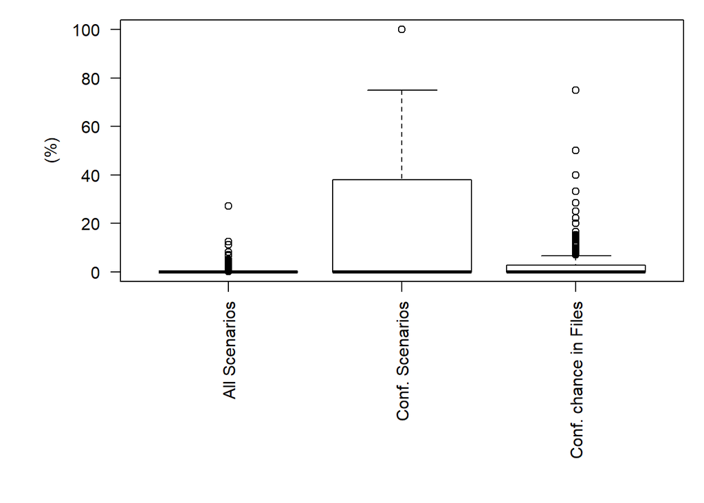